# Data Munging with Dplyr

John House PhD

March 30th 2024

# Tidyverse Collection

- Technically, tidyverse is a collection of more than a dozen packages, all with different features
- Most of the functions we are working with today come from the package: `dplyr`

# We will use the GWAS catalog data

- The GWAS catalog is maintained by NHGRI-EBI and downloaded at different levels from https://www.ebi.ac.uk/gwas/docs/file-downloads
- Contains every peer-reviewed published Variant for associations of genetic variation in humans (SNPS or indels) with studied traits at a pvalue <= 0.00001
- Since pvalues can get very very small, they are usually shown on the -log10 scale where -log10(.00001) = 5 and thus larger values of -log10(pvalue) are more significant
- The Name description of the file can be found https://www.ebi.ac.uk/gwas/docs/fileheaders#_file_headers_for_catalog_version_1_0_1
- If needed, install the data.table package with `install.packages("data.table")`

### Important: Download file here into same directory as this .RMD file

https://drive.google.com/file/d/1-KBEuyh2IA59J2iKtDAb9Guke8nqzEN2/view?usp=sharing

```r
# install.packages("data.table")
# library(data.table)
# gwas <- fread("gwas_catalog_v1.0.2-associations_e110_r2023-09-10.tsv")
# save(gwas,file =  "gwas.RData")
load(file = "gwas.RData")
```

# Get some basic understand of the dataset we just loaded

### What are the dimensions of our data?

```r
## What are the dimensions of our data?
dim(gwas)
```

```
[1] 552116     38
```

### Class of our data object in R?

```r
## Class of our data object in R?
class(gwas)
```

```
[1] "data.table" "data.frame"
```

### What are the Column Names

```r
## What are the column Names
names(gwas)
```

```
 [1] "DATE ADDED TO CATALOG"      "PUBMEDID"
 [3] "FIRST AUTHOR"               "DATE"
 [5] "JOURNAL"                    "LINK"
 [7] "STUDY"                      "DISEASE/TRAIT"
 [9] "INITIAL SAMPLE SIZE"        "REPLICATION SAMPLE SIZE"
[11] "REGION"                     "CHR_ID"
[13] "CHR_POS"                    "REPORTED GENE(S)"
[15] "MAPPED_GENE"                "UPSTREAM_GENE_ID"
[17] "DOWNSTREAM_GENE_ID"         "SNP_GENE_IDS"
[19] "UPSTREAM_GENE_DISTANCE"     "DOWNSTREAM_GENE_DISTANCE"
[21] "STRONGEST SNP-RISK ALLELE"  "SNPS"
[23] "MERGED"                     "SNP_ID_CURRENT"
[25] "CONTEXT"                    "INTERGENIC"
[27] "RISK ALLELE FREQUENCY"      "P-VALUE"
[29] "PVALUE_MLOG"                "P-VALUE (TEXT)"
[31] "OR or BETA"                 "95% CI (TEXT)"
[33] "PLATFORM [SNPS PASSING QC]" "CNV"
[35] "MAPPED_TRAIT"               "MAPPED_TRAIT_URI"
[37] "STUDY ACCESSION"            "GENOTYPING TECHNOLOGY"
```

# Get some basic understand of the dataset we just loaded

### What do the first 3 Rows of data look like

```r
## What do the first 3 Rows of data look like
head(gwas, n = 3)
```

```
  DATE ADDED TO CATALOG PUBMEDID  FIRST AUTHOR       DATE JOURNAL
1            2017-11-30 29059683 Michailidou K 2017-10-23  Nature
2            2017-11-30 29059683 Michailidou K 2017-10-23  Nature
3            2017-11-30 29059683 Michailidou K 2017-10-23  Nature
                                  LINK
1 www.ncbi.nlm.nih.gov/pubmed/29059683
2 www.ncbi.nlm.nih.gov/pubmed/29059683
3 www.ncbi.nlm.nih.gov/pubmed/29059683
                                                            STUDY DISEASE/TRAIT
1 Association analysis identifies 65 new breast cancer risk loci. Breast cancer
2 Association analysis identifies 65 new breast cancer risk loci. Breast cancer
3 Association analysis identifies 65 new breast cancer risk loci. Breast cancer
                                                INITIAL SAMPLE SIZE
1 76,192 European ancestry cases, 63,082 European ancestry controls
2 76,192 European ancestry cases, 63,082 European ancestry controls
```

[output cut: 37 more lines]

# Interrogating Column Values

### How many manuscripts are in the catalog

#### Using Base::R syntax

```r
## How many manuscripts are in the catalog
## Using Base::R syntax
length(unique(gwas$PUBMEDID))
```

```
[1] 5750
```

### We could also use tidyverse syntax and functions

#### The pull() function creates a vector from a specified column of a data.frame

```r
## We could also use tidyverse syntax and functions
## the pull() function creates a vector from a specified column of a data.frame
gwas %>%
  pull(PUBMEDID) %>% # pull out a vector from a specified column
  length() ## count how many elements in the vector
```

```
[1] 552116
```

### What about the number of unique publications

```r
gwas %>%
  pull(PUBMEDID) %>% ## pull out a vector from a specified column
  unique() %>% ## discard duplicate entries from the vector
  length() ## count how many elements in the vector
```

```
[1] 5750
```

# Interrogating Column Values

### How about the number of Mapped Traits in the catalog?

```r
gwas %>% pull(MAPPED_TRAIT) %>% unique() %>% length()
```

```
[1] 9986
```

```r
## What are the first 6 unique mapped traits?
gwas %>%
  pull(MAPPED_TRAIT) %>% ## pull out a vector from a specified column
  unique() %>% ## discard duplicate entries from the vector
  head() ## show the first 6 values
```

```
[1] "breast carcinoma"
[2] "acute myeloid leukemia"
[3] "high density lipoprotein cholesterol measurement"
[4] "response to interferon, hepatocellular carcinoma"
[5] "food allergy measurement"
[6] "peanut allergy measurement"
```

### What is the smallest pvalue in catalog

```r
gwas %>%
  pull(`P-VALUE`) %>% ## pull out a vector from a specified column
  min() ## assess the smallest value that exists in the vector
```

```
[1] "10E-10"
```

### What do you thing is going on? We know there were smaller pvalues than 10e-10

# How about we look in stead at the minus log10(pvalue) instead?

```r
gwas %>%
  pull(`PVALUE_MLOG`) %>% ## pull out a vector from a specified column
  summary() ## print some statistcs regarding this vector
```

```
     Min.   1st Qu.    Median      Mean   3rd Qu.      Max.
  -10.477     7.523    10.000    20.903    16.155 28538.699
```

### Looks like at least one pvalue isn’t coded correctly!

#### Why? Because this data set should only include pvalues at 0.00001 and smaller

```r
pvalues <- c(0.1, 0.01, 0.001, 0.0001, 0.00001, 1e-6, 1e-7, 1e-8, 1e-9)
mlog10P <- -log10(pvalues)

cbind(pvalues, mlog10P)
```

```
      pvalues mlog10P
 [1,]   1e-01       1
 [2,]   1e-02       2
 [3,]   1e-03       3
 [4,]   1e-04       4
 [5,]   1e-05       5
 [6,]   1e-06       6
 [7,]   1e-07       7
 [8,]   1e-08       8
 [9,]   1e-09       9
```

#### This means that the value 5 should be the smallest value for -log10(pvalue)

# Basic dplyr Functions

- filter(): Used to subset rows based on conditions
- slice(): Used to choose rows by position
- select(): Used to choose specific columns
- mutate(): Used to create new variables
- arrange(): Used to reorder rows
- summarize(): Used for summary statistics -group_by(): Used to for doing summary statistics by group
  - https://dplyr.tidyverse.org/reference/summarise.html
  - Can be used in concert with `group_by` for grouped summarizations

# dplyr::filter()

- filter() selects rows based on parsing a column!

### How many rows are less than 5

```r
## What was that row of data associated with the incorrectly coded -log10Pvalue??
gwas %>%
  dplyr::filter(PVALUE_MLOG < 5) ## filter for records where -log10(pvalue) < 5
```

```
  DATE ADDED TO CATALOG PUBMEDID FIRST AUTHOR       DATE
1            2023-08-15 37538507     Burley K 2023-05-14
                   JOURNAL                                 LINK
1 Res Pract Thromb Haemost www.ncbi.nlm.nih.gov/pubmed/37538507
                                                                                        STUDY
1 <i>PIK3R3</i> is a candidate regulator of platelet count in people of Bangladeshi ancestry.
   DISEASE/TRAIT                     INITIAL SAMPLE SIZE
1 Platelet count 20,218 Bangladeshi ancestry individuals
  REPLICATION SAMPLE SIZE REGION CHR_ID   CHR_POS REPORTED GENE(S)
1                    <NA> 7q22.3      7 106700379
          MAPPED_GENE UPSTREAM_GENE_ID DOWNSTREAM_GENE_ID SNP_GENE_IDS
1 CCDC71L - LINC02577  ENSG00000253276    ENSG00000228742
  UPSTREAM_GENE_DISTANCE DOWNSTREAM_GENE_DISTANCE STRONGEST SNP-RISK ALLELE
1                  39221                    74576                rs342244-T
      SNPS MERGED SNP_ID_CURRENT        CONTEXT INTERGENIC
1 rs342244      0         342244 intron_variant          1
  RISK ALLELE FREQUENCY P-VALUE PVALUE_MLOG P-VALUE (TEXT) OR or BETA
1                  0.65    3E10   -10.47712                     0.069
                95% CI (TEXT)    PLATFORM [SNPS PASSING QC] CNV   MAPPED_TRAIT
1 [0.047-0.091] unit decrease Illumina [19197360] (imputed)   N platelet count
                      MAPPED_TRAIT_URI STUDY ACCESSION
1 http://www.ebi.ac.uk/efo/EFO_0004309    GCST90271311
         GENOTYPING TECHNOLOGY
1 Genome-wide genotyping array
```

#### it was just a single record so lets remove it

```r
gwas_qc <- gwas %>%
  dplyr::filter(PVALUE_MLOG >= 5)
nrow(gwas) ## records in original dataset
```

```
[1] 552116
```

```r
nrow(gwas_qc) ## records in our cleaned dataset (qc = quality control)
```

```
[1] 552115
```

# Continued: dplyr::filter()

- We can filter on more than 1 criteria at a time
- Either in the same column or in different columns

### How many records in the catalog for the `breast carcinoma` trait on chromosome 5?

#### Logically, multiple conditions separated by commas are treated as “AND”

```r
gwas_qc %>%
  dplyr::filter(MAPPED_TRAIT == "breast carcinoma", CHR_ID == "5") %>% ## notice the double equal sign
  nrow() ## how many rows left in our catalog after filtering
```

```
[1] 197
```

### What are the unique genes from those 197 records?

```r
gwas_qc %>%
  dplyr::filter(MAPPED_TRAIT == "breast carcinoma", CHR_ID == "5") %>% ## filter all records where gene is FGF10 AND the trait is Breast Cancer
  pull(MAPPED_GENE) %>% ## Pull vector of associated genes
  unique()
```

```
 [1] "FGF10"                     ""
 [3] "KATNBL1P4 - LINC02118"     "C5orf67 - MAP3K1"
 [5] "MARCHF11 - NACAP6"         "NA - EMB"
 [7] "HSPA4"                     "PARP8 - LINC02106"
 [9] "CCL28"                     "RNU6ATAC2P - HMGN1P17"
[11] "HMGB1P47 - NA"             "NA - CEP120"
[13] "C5orf38 - NA"              "HCN1"
[15] "LINC02202 - RNF145"        "NA - RPS17P11"
[17] "ATP6AP1L"                  "SLC6A3 - LPCAT1"
[19] "PDE4D"                     "TMEM161B-AS1"
[21] "NREP"                      "KRT18P41 - LINC01187"
[23] "SLC12A2"                   "EBF1"
[25] "NA - TENM2"                "TERT - MIR4457"
[27] "ARRDC3-AS1"                "ATG10"
[29] "SUB1"                      "NNT - RNU6-381P"
```

[output cut: 24 more lines]

# Continued: dplyr::filter()

- We saw that genetic varation near the gene **`FGF10`** was associated with breast carcinoma
- Has that genetic variation near **`FGF10`** been associated with any other traits besides breast carcinoma?

```r
gwas_qc %>%
  dplyr::filter(MAPPED_GENE == "FGF10") %>% ## filter all records where gene is FGF10
  pull(MAPPED_TRAIT) %>% ## after filtering, pull the vector of mapped traits
  unique() ## give me the unique values
```

```
 [1] "breast carcinoma"                "prostate carcinoma"
 [3] "high altitude adaptation"        "vital capacity"
 [5] "forced expiratory volume"        "Alzheimer disease, age at onset"
 [7] "acne"                            "skin aging measurement"
 [9] "eye morphology measurement"      "body height"
```

### How many actual variants have been associated with **`FGF10`**?

```r
gwas_qc %>%
  dplyr::filter(MAPPED_GENE == "FGF10") %>% ## filter all records where gene is FGF10
  pull(SNPS) %>% ## after filtering, pull the vector of SNPS
  unique() ## give me the unique values
```

```
 [1] "rs13186320" "rs2121875"  "rs4498258"  "rs6859730"  "rs1482675"
 [6] "rs11742761" "rs16874036" "rs10941664" "rs78732306" "rs1448039"
[11] "rs339501"   "rs12652957" "rs11750845" "rs1448037"
```

# dplyr::slice - choosing rows by position

- slice_min()
- slice_head()
- slice_tail()
- slice_max()

### For brevity, we’ll subset the dataset using [ row, column] base functions first to only show the last 11 columns

### slice_head() gives us similar information as `head()`

```r
## using ncol() to count number of columns of our dataset
ncol(gwas_qc) ## the last column of our dataset = column 38
```

```
[1] 38
```

```r
ncol(gwas_qc) - 10 ## the value of 10 columns prior to last is 28
```

```
[1] 28
```

```r
## construct vector for 28 through 38
(ncol(gwas_qc)-10):ncol(gwas_qc)
```

```
 [1] 28 29 30 31 32 33 34 35 36 37 38
```

```r
mycolumns <- (ncol(gwas_qc)-10):ncol(gwas_qc)

gwas_qc[, mycolumns] %>% slice_head(n = 2)
```

```
  P-VALUE PVALUE_MLOG P-VALUE (TEXT) OR or BETA              95% CI (TEXT)
1   5E-15    14.30103           (EA)     0.0483 [0.036-0.06] unit increase
2   1E-24    24.00000           (EA)     0.2482    [0.2-0.3] unit decrease
       PLATFORM [SNPS PASSING QC] CNV     MAPPED_TRAIT
1 Illumina [~ 11800000] (imputed)   N breast carcinoma
2 Illumina [~ 11800000] (imputed)   N breast carcinoma
                      MAPPED_TRAIT_URI STUDY ACCESSION
1 http://www.ebi.ac.uk/efo/EFO_0000305      GCST004988
2 http://www.ebi.ac.uk/efo/EFO_0000305      GCST004988
         GENOTYPING TECHNOLOGY
1 Genome-wide genotyping array
2 Genome-wide genotyping array
```

### slice_tail() gives us similar information as `tail()`

```r
gwas_qc[, mycolumns] %>% slice_tail(n = 2)
```

```
  P-VALUE PVALUE_MLOG P-VALUE (TEXT) OR or BETA             95% CI (TEXT)
1   3E-15    14.52288                      0.60 [0.44-0.76] unit increase
2   2E-46    45.69897                      0.28 [0.24-0.32] unit increase
    PLATFORM [SNPS PASSING QC] CNV                MAPPED_TRAIT
1 Illumina [9097073] (imputed)   N carboxylic acid measurement
2 Illumina [9097073] (imputed)   N         guanine measurement
                      MAPPED_TRAIT_URI STUDY ACCESSION
1 http://www.ebi.ac.uk/efo/EFO_0010468    GCST90257503
2 http://www.ebi.ac.uk/efo/EFO_0801165    GCST90257509
         GENOTYPING TECHNOLOGY
1 Genome-wide genotyping array
2 Genome-wide genotyping array
```

### slice_max() allows us to take a slice based on the largest and smallest values of a numerical/integer column

```r
gwas_qc[, mycolumns] %>% slice_max(`PVALUE_MLOG`, n=5)
```

```
   P-VALUE PVALUE_MLOG                    P-VALUE (TEXT) OR or BETA
1 2E-28539    28538.70                              (EA)    2.60527
2 3E-26677    26676.52                                      0.70200
3 2E-22935    22934.70                                      0.74870
4 6E-22136    22135.22 (EA, South Asian, Afro-Caribbean)    1.70000
5 4E-19380    19379.40                                      1.02095
                 95% CI (TEXT)                PLATFORM [SNPS PASSING QC] CNV
1    [2.59-2.62] unit decrease             Illumina [11532091] (imputed)   N
2     [0.7-0.71] unit increase Affymetrix, Illumina [20535842] (imputed)   N
3    [0.74-0.75] unit increase            Affymetrix [9000000] (imputed)   N
4 [1.7-1.7] ln nmol/L increase            Affymetrix [9829003] (imputed)   N
5  [1.01-1.03] nmol/l decrease                   NR [19000000] (imputed)   N
               MAPPED_TRAIT                     MAPPED_TRAIT_URI
1                 eye color http://www.ebi.ac.uk/efo/EFO_0003949
2     bilirubin measurement http://www.ebi.ac.uk/efo/EFO_0004570
3     bilirubin measurement http://www.ebi.ac.uk/efo/EFO_0004570
4 lipoprotein A measurement http://www.ebi.ac.uk/efo/EFO_0006925
5 lipoprotein A measurement http://www.ebi.ac.uk/efo/EFO_0006925
  STUDY ACCESSION        GENOTYPING TECHNOLOGY
1      GCST012219 Genome-wide genotyping array
2    GCST90018973 Genome-wide genotyping array
3    GCST90019521 Genome-wide genotyping array
4      GCST011087 Genome-wide genotyping array
5      GCST012232 Genome-wide genotyping array
```

# dplyr::select()

- Its a pain to keep having all the columns when we may only be interested in a few!
- select() chooses columns
  - Can be done with integers - as in select the first column with a 1
  - Can be done with column names
- We can also **`RENAME`** columns while selecting!
- We can also **`REORDER`** columns while selecting!

### Select first 3 columns of our catalog

```r
gwas_qc %>%
  dplyr::select(1,2,3) %>%
  head()
```

```
  DATE ADDED TO CATALOG PUBMEDID  FIRST AUTHOR
1            2017-11-30 29059683 Michailidou K
2            2017-11-30 29059683 Michailidou K
3            2017-11-30 29059683 Michailidou K
4            2017-11-30 29059683 Michailidou K
5            2017-11-30 29059683 Michailidou K
6            2017-11-30 29059683 Michailidou K
```

# dplyr::select(): continued

### Select columns by name and rename some of them!

```r
gwas_qc %>%
  dplyr::select(Catalog_Date = "DATE ADDED TO CATALOG", ## renaming to "Date"
                Trait = MAPPED_TRAIT, # Trait (a renaming of "MAPPED_TRAIT")
                SNPS, ## 3 column to be selected is SNPS, but not renaming it
                Nearest_Gene = MAPPED_GENE, ## renaming to "Nearest_Gene"
                PVALUE_MLOG) %>% ## last column is the same name and -log10(pvalue) column
  slice_max(PVALUE_MLOG, n = 10) ## take the records (rows) with the 10 largest values of -log10(pvalue)
```

```
   Catalog_Date                                           Trait       SNPS
1    2021-08-24                                       eye color  rs1129038
2    2021-12-14                           bilirubin measurement rs35754645
3    2021-06-29                           bilirubin measurement rs10929302
4    2021-02-05                       lipoprotein A measurement rs10455872
5    2021-08-24                       lipoprotein A measurement rs10455872
6    2021-06-29                       lipoprotein A measurement rs74617384
7    2021-06-29                           bilirubin measurement rs10929302
8    2022-11-17 low density lipoprotein cholesterol measurement     rs7412
9    2020-07-23                  cutaneous melanoma, hair color rs12913832
10   2023-02-23           vitamin D-binding protein measurement     rs7041
                                                      Nearest_Gene PVALUE_MLOG
1                                                     HERC2, HERC2   28538.699
2  UGT1A8, UGT1A5, UGT1A9, UGT1A6, UGT1A4, UGT1A7, UGT1A3, UGT1A10   26676.523
3  UGT1A6, UGT1A7, UGT1A10, UGT1A4, UGT1A9, UGT1A8, UGT1A5, UGT1A3   22934.699
4                                                              LPA   22135.222
5                                                              LPA   19379.398
6                                                              LPA   19215.000
7  UGT1A6, UGT1A7, UGT1A10, UGT1A4, UGT1A9, UGT1A8, UGT1A5, UGT1A3   13049.046
8                                                             APOE    9629.000
9                                                     HERC2, HERC2    9236.699
10                                                              GC    7245.000
```

# dplyr::select(): continued

### Put it all together - filter, take top 10 smallest pvalues, and display columns of interest by name

```r
gwas_qc %>%
  dplyr::filter(MAPPED_TRAIT == "breast carcinoma") %>%  ## select only the rows for breast cancer
  slice_max(`PVALUE_MLOG`, n=10) %>% ## take the 10 largest values of -log10(pvalue)
  dplyr::select(Trait = MAPPED_TRAIT, ## select our columns of interest
                CHR = CHR_ID,
                POS = CHR_POS,
                SNPS,
                PVALUE_MLOG,
                `OR or BETA`,
                PUBMEDID) -> mytabledata
  kbl(mytabledata, caption = "The 10 Most Significant Breast Carcinoma GWAS Catalog Entries") %>%
  kable_styling(bootstrap_options = c("striped", "hover"), full_width = F)
```

The 10 Most Significant Breast Carcinoma GWAS Catalog Entries

| Trait | CHR | POS | SNPS | PVALUE_MLOG | OR or BETA | PUBMEDID |
| --- | --- | --- | --- | --- | --- | --- |
| breast carcinoma | 10 | 121580918 | rs35054928 | 321.6990 | 1.2700 | 29059683 |
| breast carcinoma | 10 | 121580797 | rs2981578 | 290.6990 | 0.8100 | 32139696 |
| breast carcinoma | 10 | 121580797 | rs2981578 | 245.0000 | 1.2300 | 29059683 |
| breast carcinoma | 16 | 52565276 | rs4784227 | 239.6990 | 1.2400 | 32139696 |
| breast carcinoma | 16 | 52565276 | rs4784227 | 200.1549 | 1.2300 | 29059683 |
| breast carcinoma | 10 | 121577821 | rs2981579 | 169.6990 | 1.2700 | 23535729 |
| breast carcinoma | 10 | 121577821 | rs2981579 | 163.2218 | 1.2700 | 25751625 |
| breast carcinoma | 11 | 69516650 | rs78540526 | 130.6990 | 0.2758 | 29059683 |
| breast carcinoma | 10 | 121577821 | rs2981579 | 128.0000 | 1.2700 | 25751625 |
| breast carcinoma | 16 | 52552429 | rs3803662 | 116.3979 | 1.2400 | 25751625 |

# arrange(): Used to reorder rows

- Same as a sort
- Choose column(s) to sort
- More than one column means sort by first column, then in the other one

### Arrange by Chromosome!

```r
mytabledata %>%
  arrange(CHR) %>% ## Arrange by Chromosome!
  kbl(caption = "The 10 Most Significant Breast Carcinoma Catalog Entries") %>%
  kable_styling(bootstrap_options = c("striped", "hover"), full_width = F)
```

The 10 Most Significant Breast Carcinoma Catalog Entries

| Trait | CHR | POS | SNPS | PVALUE_MLOG | OR or BETA | PUBMEDID |
| --- | --- | --- | --- | --- | --- | --- |
| breast carcinoma | 10 | 121580918 | rs35054928 | 321.6990 | 1.2700 | 29059683 |
| breast carcinoma | 10 | 121580797 | rs2981578 | 290.6990 | 0.8100 | 32139696 |
| breast carcinoma | 10 | 121580797 | rs2981578 | 245.0000 | 1.2300 | 29059683 |
| breast carcinoma | 10 | 121577821 | rs2981579 | 169.6990 | 1.2700 | 23535729 |
| breast carcinoma | 10 | 121577821 | rs2981579 | 163.2218 | 1.2700 | 25751625 |
| breast carcinoma | 10 | 121577821 | rs2981579 | 128.0000 | 1.2700 | 25751625 |
| breast carcinoma | 11 | 69516650 | rs78540526 | 130.6990 | 0.2758 | 29059683 |
| breast carcinoma | 16 | 52565276 | rs4784227 | 239.6990 | 1.2400 | 32139696 |
| breast carcinoma | 16 | 52565276 | rs4784227 | 200.1549 | 1.2300 | 29059683 |
| breast carcinoma | 16 | 52552429 | rs3803662 | 116.3979 | 1.2400 | 25751625 |

# arrange(): continued

### Arrange by Chromosome and then Largest -10log(pvalue) next

#### arrange(CHR) would sort by smallest to largest

#### arrange(desc(CHR)) would sort by largest to smallest

```r
# This time arrange by Chromosome and THEN Position
mytabledata %>%
  arrange(CHR, desc(PVALUE_MLOG)) %>% ## Arrange by Chromosome and then by largest to smallest **PVALUE_MLOG**
  kbl(caption = "The 10 Most Significant Breast Carcinoma Catalog Entries") %>%
  kable_styling(bootstrap_options = c("striped", "hover"), full_width = F)
```

The 10 Most Significant Breast Carcinoma Catalog Entries

| Trait | CHR | POS | SNPS | PVALUE_MLOG | OR or BETA | PUBMEDID |
| --- | --- | --- | --- | --- | --- | --- |
| breast carcinoma | 10 | 121580918 | rs35054928 | 321.6990 | 1.2700 | 29059683 |
| breast carcinoma | 10 | 121580797 | rs2981578 | 290.6990 | 0.8100 | 32139696 |
| breast carcinoma | 10 | 121580797 | rs2981578 | 245.0000 | 1.2300 | 29059683 |
| breast carcinoma | 10 | 121577821 | rs2981579 | 169.6990 | 1.2700 | 23535729 |
| breast carcinoma | 10 | 121577821 | rs2981579 | 163.2218 | 1.2700 | 25751625 |
| breast carcinoma | 10 | 121577821 | rs2981579 | 128.0000 | 1.2700 | 25751625 |
| breast carcinoma | 11 | 69516650 | rs78540526 | 130.6990 | 0.2758 | 29059683 |
| breast carcinoma | 16 | 52565276 | rs4784227 | 239.6990 | 1.2400 | 32139696 |
| breast carcinoma | 16 | 52565276 | rs4784227 | 200.1549 | 1.2300 | 29059683 |
| breast carcinoma | 16 | 52552429 | rs3803662 | 116.3979 | 1.2400 | 25751625 |

# dplyr::mutate() - New variable creation

### We can use same variable name and overwrite a new definition based on either its values or other columns

```r
mytabledata %>%
  head()
```

```
             Trait CHR       POS       SNPS PVALUE_MLOG OR or BETA PUBMEDID
1 breast carcinoma  10 121580918 rs35054928    321.6990       1.27 29059683
2 breast carcinoma  10 121580797  rs2981578    290.6990       0.81 32139696
3 breast carcinoma  10 121580797  rs2981578    245.0000       1.23 29059683
4 breast carcinoma  16  52565276  rs4784227    239.6990       1.24 32139696
5 breast carcinoma  16  52565276  rs4784227    200.1549       1.23 29059683
6 breast carcinoma  10 121577821  rs2981579    169.6990       1.27 23535729
```

```r
mytabledata %>%
  mutate(PVALUE_MLOG = round(PVALUE_MLOG,0),
         POS = as.numeric(POS),
         CHR = as.numeric(CHR)) %>%
  head()
```

```
             Trait CHR       POS       SNPS PVALUE_MLOG OR or BETA PUBMEDID
1 breast carcinoma  10 121580918 rs35054928         322       1.27 29059683
2 breast carcinoma  10 121580797  rs2981578         291       0.81 32139696
3 breast carcinoma  10 121580797  rs2981578         245       1.23 29059683
4 breast carcinoma  16  52565276  rs4784227         240       1.24 32139696
5 breast carcinoma  16  52565276  rs4784227         200       1.23 29059683
6 breast carcinoma  10 121577821  rs2981579         170       1.27 23535729
```

# dplyr::mutate(): continued

### We can use to create new variables

```r
mytabledata %>%
  mutate(Is_CHR16 = ifelse(CHR == "16", "Yes", "No")) %>%  ## new variable
  dplyr::select(Trait, Is_CHR16, everything()) %>%  ## Note the helper function `everthing()`
  head()
```

```
             Trait Is_CHR16 CHR       POS       SNPS PVALUE_MLOG OR or BETA
1 breast carcinoma       No  10 121580918 rs35054928    321.6990       1.27
2 breast carcinoma       No  10 121580797  rs2981578    290.6990       0.81
3 breast carcinoma       No  10 121580797  rs2981578    245.0000       1.23
4 breast carcinoma      Yes  16  52565276  rs4784227    239.6990       1.24
5 breast carcinoma      Yes  16  52565276  rs4784227    200.1549       1.23
6 breast carcinoma       No  10 121577821  rs2981579    169.6990       1.27
  PUBMEDID
1 29059683
2 32139696
3 29059683
4 32139696
5 29059683
6 23535729
```

# dplyr::summarize() - getting summary information from a dataset

- https://dplyr.tidyverse.org/reference/summarise.html
  - Center: mean(), median()
  - Spread: sd(), IQR(), mad()
  - Range: min(), max(),
  - Position: first(), last(), nth(),
  - Count: n(), n_distinct()
  - Logical: any(), all()
- Can be used in concert with group_by for grouped summarizations

```r
gwas_qc %>% summarise(Number_entries = n(),
                      Number_Distinct_Journals = n_distinct(JOURNAL),
                      Mean_PVALUE_MLOG = mean(PVALUE_MLOG),
                      Avg_upstream_gene_distance = mean(UPSTREAM_GENE_DISTANCE, na.rm = T))
```

```
  Number_entries Number_Distinct_Journals Mean_PVALUE_MLOG
1         552115                      742         20.90327
  Avg_upstream_gene_distance
1                   424170.4
```

# dplyr::summarize(): continued

- Can be used in concert with group_by() for grouped summarizations

```r
gwas_qc %>%
  dplyr::filter(grepl(pattern = "cancer", ignore.case = T, x = MAPPED_TRAIT)) %>%  ## Filter to only records with Mapped Trait containing the word "cancer"
  group_by(MAPPED_TRAIT) %>% ## Perform this operations by group for all records within each MAPPED_TRAIT

  summarise(Number_entries = n(),
            Number_Distinct_Journals = n_distinct(JOURNAL),
            Mean_PVALUE_MLOG = mean(PVALUE_MLOG)) %>%
  slice_head(n = 10)
```

```
# A tibble: 10 × 4
   MAPPED_TRAIT           Number_entries Number_Distinct_Jour…¹ Mean_PVALUE_MLOG
   <chr>                           <int>                  <int>            <dbl>
 1 BRCAX breast cancer                19                      1             6.63
 2 Uterine leiomyoma, es…             14                      1            17.8
 3 Uterine leiomyoma, es…             17                      1            12.2
 4 alcohol consumption m…              2                      1             7.35
 5 bile duct cancer                    1                      1             8
 6 breast cancer                       6                      1             5.87
 7 breast cancer anti-es…              8                      4            38.8
 8 breast cancer, lung c…             18                      1            17.4
 9 breast cancer, ovaria…             27                      1            26.8
10 breast carcinoma, obs…             18                      1             5.46
# ℹ abbreviated name: ¹Number_Distinct_Journals
```

# Putting it all together

- For Traits with cancer
- Graph the distribution of variants found for each chromosome

```r
gwas_qc %>%
  dplyr::filter(grepl(pattern = "cancer", ignore.case = T, x = MAPPED_TRAIT), ## Filter to records with Mapped Trait containing the word "cancer"
                PVALUE_MLOG > 7.30103) %>%  ## only look at records at genome wide significance of -log10(5e-8) or larger
  ### There are messed up values for CHR in the database - creating numeric version gets rid of many!
  mutate(CHR = as.numeric(CHR_ID)) %>%  ## Create a numeric version of the character variable for chromosome
  group_by(CHR) %>% ## group by chromosome
  dplyr::filter(CHR %in% 1:22) %>% ## Only look at non-sex related chromosomes
  summarize(Catalog_Entries = n(),
            Unique_Variants = n_distinct(SNPS),
            Unique_Genes = n_distinct(MAPPED_GENE),
            Publications = n_distinct(PUBMEDID)) -> Cancer_GWAS_Summary
Cancer_GWAS_Summary %>%
  kbl(caption = "GWAS Catalog Summary of Cancer Variants by Chromosome") %>%
  kable_classic_2(full_width = F)
```

GWAS Catalog Summary of Cancer Variants by Chromosome

| CHR | Catalog_Entries | Unique_Variants | Unique_Genes | Publications |
| --- | --- | --- | --- | --- |
| 1 | 71 | 56 | 46 | 32 |
| 2 | 69 | 62 | 49 | 30 |
| 3 | 45 | 33 | 25 | 23 |
| 4 | 25 | 22 | 17 | 13 |
| 5 | 86 | 57 | 31 | 37 |
| 6 | 94 | 81 | 55 | 24 |
| 7 | 27 | 24 | 20 | 13 |
| 8 | 106 | 58 | 34 | 37 |
| 9 | 39 | 31 | 19 | 21 |
| 10 | 102 | 59 | 25 | 35 |
| 11 | 68 | 49 | 35 | 32 |
| 12 | 81 | 51 | 37 | 30 |
| 13 | 27 | 21 | 15 | 10 |
| 14 | 29 | 20 | 15 | 14 |
| 15 | 43 | 33 | 25 | 23 |
| 16 | 54 | 43 | 31 | 20 |
| 17 | 53 | 31 | 18 | 22 |
| 18 | 33 | 14 | 8 | 25 |
| 19 | 54 | 46 | 32 | 26 |
| 20 | 92 | 61 | 37 | 31 |
| 21 | 4 | 4 | 4 | 4 |
| 22 | 18 | 15 | 10 | 7 |

# And a plot!

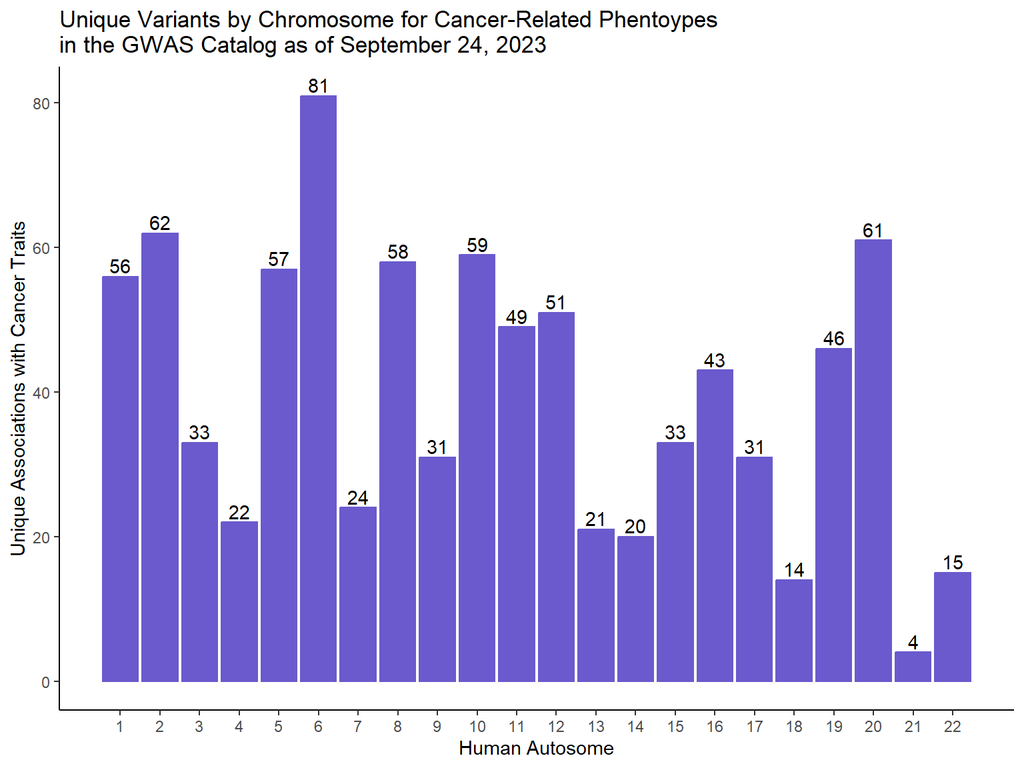

```r
library(ggplot2)

Cancer_GWAS_Summary %>%
  ggplot(aes(x = CHR, y = Unique_Variants)) +
  geom_bar(stat = "identity", color = "slateblue", fill = "slateblue") +
  scale_x_continuous(breaks = 1:22) +
  xlab("Human Autosome") +
  ylab("Unique Associations with Cancer Traits") +
  ggtitle("Unique Variants by Chromosome for Cancer-Related Phentoypes\nin the GWAS Catalog as of September 24, 2023")+
  geom_text(aes(label=Unique_Variants), position=position_dodge(width=0.9), vjust=-0.25) +
  theme_classic()
```

# Excercises !

# Assignment 4 Q1

### How many different **Unique** Mapped Traits have been found on each Chromosome?

- Note: this is independent of cancer related traits
- Print a table to the screen by chromosome of this information

```r
load("gwas.RData")
names(gwas)
```

```
 [1] "DATE ADDED TO CATALOG"      "PUBMEDID"
 [3] "FIRST AUTHOR"               "DATE"
 [5] "JOURNAL"                    "LINK"
 [7] "STUDY"                      "DISEASE/TRAIT"
 [9] "INITIAL SAMPLE SIZE"        "REPLICATION SAMPLE SIZE"
[11] "REGION"                     "CHR_ID"
[13] "CHR_POS"                    "REPORTED GENE(S)"
[15] "MAPPED_GENE"                "UPSTREAM_GENE_ID"
[17] "DOWNSTREAM_GENE_ID"         "SNP_GENE_IDS"
[19] "UPSTREAM_GENE_DISTANCE"     "DOWNSTREAM_GENE_DISTANCE"
[21] "STRONGEST SNP-RISK ALLELE"  "SNPS"
[23] "MERGED"                     "SNP_ID_CURRENT"
[25] "CONTEXT"                    "INTERGENIC"
[27] "RISK ALLELE FREQUENCY"      "P-VALUE"
[29] "PVALUE_MLOG"                "P-VALUE (TEXT)"
[31] "OR or BETA"                 "95% CI (TEXT)"
[33] "PLATFORM [SNPS PASSING QC]" "CNV"
[35] "MAPPED_TRAIT"               "MAPPED_TRAIT_URI"
[37] "STUDY ACCESSION"            "GENOTYPING TECHNOLOGY"
```

# Assignment Q2

### Create a Bar Chart of those values by Chromosome

# Assignment Q3

### What 5 Mapped_Trait contains the most unique SNPS associated with them in the gwas catalog

# Assignment Q4

### What MAPPED_GENE has the most **unique** gwas MAPPED_TRAITS associated with it?

- Print those unique traits to the screen along with the number of unique variants for each trait as a table